# Experiment 12: Correlation analysis- Spearman Rank Correlation Coefficient

siju.swamy@saintgits.org

4/23/2022

## Aim

1. To find the Spearman rank correlation coefficient of the given bivariate data

## Packages used and syntax of R methods

Functions from `stat` package (which is loaded by default).

**Pearson correlation (r)**, which measures a linear dependence between two variables (x and y). It’s also known as a parametric correlation test because it depends to the distribution of the data. It can be used only when x and y are from normal distribution. The plot of $y = f(x)$ is named the linear regression curve. The Spearman correlation method computes the correlation between the rank of x and the rank of y variables.

$$rho = \frac{\sum(x' -
m_{x'})(y'_i - m_{y'})}{\sqrt{\sum(x' - m_{x'})^2
\sum(y' - m_{y'})^2}}$$

where $x'=rank(x)$ and $y'=rank(y)$.

Correlation coefficient can be computed using the functions `cor()` or `cor.test()`:

**Syntax:**

> `cor(x, y, method = c("pearson", "kendall", "spearman"))` `cor.test(x, y, method=c("pearson", "kendall", "spearman"))`

> Note: If the data contain missing values, use the following R code to handle missing values by case-wise deletion.

`cor(x, y, method = "pearson", use = "complete.obs")`

## Algorithm

- Step 1: Assign the inputs for required correlation model
- Step 2: Calculate the correlation coefficient
- Step 3: Interpret the result

> *Case:* The scores for nine students in history and algebra are as follows:

$\begin{array}{|l|cccccccc|}\hline \text{History}:&35& 23& 47& 17& 10& 43& 9& 6&28\\\hline \text{Algebra}:&30& 33&45&23&8&49&12&4&31\\\hline \end{array}$

## R code

```r
# loading data
History=c(35,23,47,17,10,43,9,6,28)
Algebra=c(30,33,45,23,8,49,12,4,31)
```

### Calculating correlation coefficient

```r
ress3=cor.test(History,Algebra,method='pearson')
ress3
```

```
##
##  Pearson's product-moment correlation
##
## data:  History and Algebra
## t = 8.0379, df = 7, p-value = 8.844e-05
## alternative hypothesis: true correlation is not equal to 0
## 95 percent confidence interval:
##  0.7740125 0.9896747
## sample estimates:
##       cor
## 0.9498663
```

### Plotting the variables

```r
my_data=data.frame(History=History,Algebra=Algebra)
head(my_data)
```

```
##   History Algebra
## 1      35      30
## 2      23      33
## 3      47      45
## 4      17      23
## 5      10       8
## 6      43      49
```

```r
library(ggpubr)
```

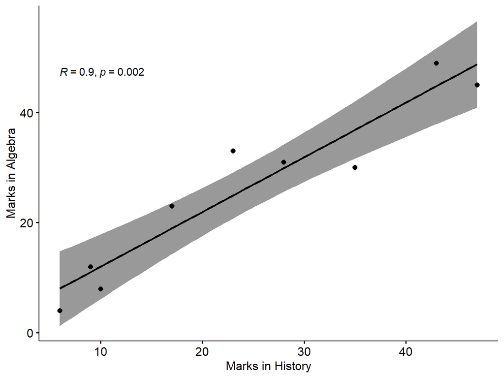

Scatter plot with smooth fit curve

```r
ggscatter(my_data, x = "History", y = "Algebra",
          add = "reg.line", conf.int = TRUE,
          cor.coef = TRUE, cor.method = "spearman",
          xlab = "Marks in History", ylab = "Marks in Algebra")
```

## Results & discussions

Correlation coefficient of given bivariate data is calculated using built-in function in `stats` package.